# Avance 2 - Estadística para el Análisis Político II

Georgia Tito (20190632) y Meloddy Saldarriaga (20190185)

10/14/2021

Link repositorio en github: https://github.com/meloddysv/Ratatata.git

# Introducción del reporte final

Desde finales de la Segunda Guerra Mundial, hubo una creciente proliferación de organizaciones internacionales con nuevas capacidades y competencias dedicadas a la cooperación política y económica (Pastor 1986). Gracias al Sistema de Naciones Unidas, se crearon organismos para que los Estados puedan encargarse de velar por una diversidad de temas, especialmente, tras la falla de la Liga de las Naciones al querer velar por la paz y seguridad a nivel mundial. Entre las distintas organizaciones que se crearon destaca la Organización Mundial de la Salud (OMS), como las que estaban vinculadas al Sistema de Bretton Woods: el Banco Mundial, el Fondo Monetario Internacional y el GATT, posteriormente conocido como la Organización Mundial del Comercio. Paralelamente, surgieron organizaciones regionales de integración o vinculación por temas específicos, como la Unión Africana, la Unión Europea y la Organización de Estados Americanos.

Todas estas se encargan de canalizar la cooperación internacional, y se convierten en plataformas mediante las cuales otros Sujetos de Derecho Internacional y actores internacionales pueden adquirir visibilidad, y discutir sobre diversos temas como la protección de los derechos humanos, el medio ambiente, el patrimonio común de la humanidad, etc. Más aún cuando debido a la creciente interdependencia entre países, se observan problemáticas que no son posibles de resolver de manera aislada. En este contexto, el multilateralismo, característica del orden liberal, vislumbraba un camino hacia la gobernanza global. Sin embargo, en los últimos años, se ha observado un fuerte descontento por diversos sectores de la población sobre los efectos de la labor de las organizaciones internacionales. Según Adler y Drieschova (2021), estas solían conformar parte de la autoridad epistémica, es decir, eran instituciones y comunidades en las que se confiaba por producir conocimientos y estándares que representaban la verdad (conocimiento compartido colectivamente). No obstante, tras la llegada de grupos y gobiernos, como el de Trump y Andrés Manuel López Obrador, que critican a las organizaciones y las comunidades de seguridad pluralistas establecidas, el futuro de las organizaciones es incierto.

Por ello, resulta interesante analizar el grado de confianza que tienen las personas en las organizaciones internacionales en los últimos años. Como menciona Torgler (2007), son pocos los estudios empíricos realizados en las últimas décadas para medir la confianza, por lo que realiza un estudio sobre la confianza en las Naciones Unidas, mediante indicadores como la confianza en la política, confianza social, corrupción, identificación geográfica y globalización usando la data de World Values Survey que tomaba en consideración 38 países. Asimismo, destaca el estudio de Hessami (2011), sobre los determinantes de la confianza en organizaciones internacionales económicas en la región europea mediante los resultados del Eurobarómetro. Se sugiere que las variables relacionadas a características individuales como la percepción de los efectos de la globalización afectan la actitud que se tiene sobre estas.

Sin embargo, es igual de importante resaltar que a nivel regional estas organizaciones internacionales participaron y participan activamente en el ámbito peruano. Por un lado, destaca Naciones Unidas, la cual en el año 2017 firmó un Marco de Cooperación con el Gobierno peruano hasta el 2021. Esto como una herramienta de planeación estratégica para promover y llevar a cabo la Agenda para el Desarrollo del 2030 a través del trabajo con Agencias, Fondos y Programas brindados por el Sistema de Naciones Unidas (ONU, 2017). De esta forma se impulsan proyectos para el fin de la pobreza, reducción de hambre, incremento de salud y bienestar, educación de calidad, igualdad de género, reducción de las desigualdades y 10 objetivos adicionales (ONU, 2017).

Por otro lado, se observa que la OEA durante el 2017-2020 participó activamente en la dinámica peruana. Por ejemplo, durante el 2017, junto al gobierno peruano, comenzó los preparativos para la VIII Cumbre de las Américas que se llevaría a cabo en el 2018 y reuniría a los Jefes de Estado del Hemisferio con la temática “Gobernabilidad democrática frente a la corrupción” para que se siga fortaleciendo la participación de la ciudadanía y de otros actores sociales (OEA, 2017). Así también, la OEA realizó la “Misión de Observación Electoral” en territorio peruano el año 2020, por lo que felicitó la manera en cómo las elecciones se llevaron a cabo y el cumplimiento de las recomendaciones y observaciones brindadas en procesos electorales anteriores (OEA, 2021).

Además, por su parte, el Fondo Monetario Internacional realizó la “Cuarta Misión de Asistencia Técnica al INEI” en el 2018, esto con el objetivo de analizar los avances por sectores institucionales en cuentas nacionales anuales, sobre todo en cuentas financieras y balances (INEI, 2018). De esta forma, el FMI brindó mayores herramientas, fuentes y métodos para una mejor elaboración de las cuentas trimestrales de los sectores institucionales (INEI, 2018). Como se aprecia estas organizaciones han tenido gran impacto durante el periodo a estudiar, por lo que deben de haber generado reacciones positivas o negativas en la población peruana.

Teniendo en consideración que las actividades de la Organización de las Naciones Unidas, el Fondo Monetario Internacional y la Organización de Estados Americanos, han sido constantes en el territorio peruano el presente trabajo tendrá como pregunta de investigación: ¿Qué factores determinan la confianza en las organizaciones internacionales en el Perú durante el periodo 2018-2020? Por ende, el objetivo principal será definir qué variables impactan en mayor y menor medida la confianza de la población peruana en las organizaciones internacionales, sabiendo que existe un continuo descontento respecto al trabajo que han venido realizando. Dentro de los objetivos específicos, este trabajo desea saber cuanto impactan las variables relacionadas con libertad, sexo, democracia y edad. Así como también con las variables ideología, interés en la política, ingresos socioeconómicos, educación y proximidad al mundo.

Como se mencionaba, la bibliografía sobre la confianza en las organizaciones internacionales no es extensa, pero la relación que puede tener con las variables propuestas es de sumo interés. Sobre la variable **sexo**, diversos estudios demuestran que las organizaciones internacionales económicas, como el Banco Mundial y el Fondo Monetario Internacional, dictaminan medidas de austeridad y remoldean las economías para que esten orientadas al libre mercado, lo que afecta negativamente a las mujeres (Sparr 1998). Cuando se cortan los servicios sociales como de educación o salud, se confía en que ello será cubierto por madres, hijas, tías, abuelas, haciendo hincapié en la división sexual del trabajo en continentes como África y América Latina, por lo que se intensifica el trabajo doméstico no remunerado en el sector informal (Sparr 1998). Asimismo, en relación a las Naciones Unidas, se cuestiona la responsabilidad de la organizaciones internacionales por la violación de derechos humanos que se llevan a cabo en las intervenciones humanitarias y misiones de paz, como la jerarquía en torno a la distinción entre hombres y mujes en documentos como los Principios Rectores sobre las Empresas y los Derechos Humanos de las Naciones Unidas (Handl y Simons 2019). Por todo ello, se esperaría que las mujeres confíen menos en las organizaciones internacionales económicas que los hombres (Edwards 2009: 190).

Por su parte, sobre las variables **nivel educativo** e **ingresos socioeconómicos**, se encontró que el éxito profesional, relacionado con ambas variables, puede aumentar la confianza de otras personas como su nivel de información sobre hechos actuales, por lo que pueden conocer mejor los esfuerzos de la ONU y otras organizaciones internacionales para darles respaldo (Torgler 2007). En relación a la **ideología**, por ejemplo, en un análisis del caso estadounidense, se encuentra que los republicanos y las élites políticas conservadoras son más pesimistas respecto a la naturaleza de las relaciones internacionales, y corrientes realistas sugieren que la cesión de soberanía en organizaciones internacionales no es favorable para la política interna (Brewer et al., 2004). En esta misma línea, en un artículo sobre el multilateralismo en EE.UU. pos Segunda Guerra Mundial, Rathbun (2011) encontró que la izquierda está más dispuesta que la derecha hacia las soluciones acordadas debido a su naturaleza “más confiada”, lo que podría trasladarse a otras regiones. Asimismo, en torno a la variable **edad**, se concluye que las experiencias que los estadounidenses mayores han tenido durante sus años de formación (conflictos armados) generan una desconfianza generalizada hacia otras naciones, por lo que no creen en la efectividad de las instituciones internacionales (Brewer et al., 2004).

Sobre el **interés en la política**, Torgler (2007) encuentra en un estudio sobre la confianza en la ONU que, si las personas que son cínicas y pesimistas sobre la política interna, también tendrían esa misma percepción sobre las organizaciones internacionales, más aún si creen que su gobierno no puede satisfacer sus necesidades y derechos, las OI menos. En esa misma línea, sobre el **interés en la democracia**, hubo años en los que los gobiernos de latinoamérica, especialmente del Perú, distaban mucho de ser calificados como democráticos. Es por ello que, en la actualidad, la democracia no es un tema que pasa de manera desapercibida. Diversos son los organismos que velan por su protección y difusión, entre estos se encuentran las organizaciones internacionales como la ONU y OEA, quienes la tienen como pilar en su actuar. El actuar de estas organizaciones se refleja en las diversas resoluciones, tratados, acuerdos, declaraciones, mecanismos de supervisión, entre otros, que han emitido a lo largo de los últimos 60 años a favor de la promoción de valores democráticos (Nuño, 2020).

Por otra parte, la decisión de brindar o no confianza a las organizaciones internacionales se basa en los sucesos o hechos del entorno de los encuestados, así como también en los **objetivos** que estos se han establecido (Cabeza de Vergara y Muñoz, 2010). Finalmente, día a día vivimos en un mundo cada vez más globalizado e interconectado, este tema no solo afecta a actores de otra naturaleza, sino también a nosotros como individuos. La globalización implica flujos, no solo materiales o económicos, sino también de ideas, conocimiento e información (Flores, 2016). Por ende, la información del actuar y planes de operación de las organizaciones internacionales no es privada o de difícil acceso, al contrario todos pueden acceder a ella mediante internet, porque nos encontramos **más cerca del mundo**.

Después de la revisión bibliográfica de las variables a usar, las hipótesis de este trabajo son las siguientes:

1. Es probable que las variables “interés en la política” y “edad” expliquen en mayor medida la confianza en organizaciones internacionales que la variable “sexo”, ya que a mayor edad y mayor interes en la política, estarán más informados sobre los planes de acción de las organizaciones a estudiar

2. Luego de la revisión de literatura, las personas ya sea que prefieren libertad, seguridad o igualdad tendrán un alto grado de confianza en las organizaciones internacionales, ya que estos son algunos de los valores que promueven
3. Las personas con mayor interés y confianza en la democracia, serán las que le brinden un alto grado de confianza y credibilidad a las organizaciones internacionales

# 0. Preparación de la data

### Leyendo la base de datos **World Values Survey Association (2017-2020)**

```r
setwd("~/Documents/GitHub/Ratatata")
library(rio)
WVS <-import("WVS_Peru.xlsx")
```

### Crear subset para el trabajo [Perú]

```r
data=subset(WVS,select=c(`Q4: Important in life: Politics`, `Q48: How much freedom of choice and control`, `Q49: Satisfaction with your life`, `Q50: Satisfaction with financial situation of household`, `Q82_OAS: Confidence: The Organization of American States (OAE)`, `Q83: Confidence: The United Nations (UN)`, `Q84: Confidence: International Monetary Found (IMF)`, `Q146: Worries: A war involving my country`, `Q147: Worries: A terrorist attack`, `Q149: Freedom and Equality - Which more important`, `Q150: Freedom and security - Which more important`, `Q152: Aims of country: first choice`, `Q154: Aims of respondent: first choice`, `Q199: Interest in politics`, `Q240: Left-right political scale`, `Q250: Importance of democracy`, `Q259: Feel close to the world`, `Q260: Sex`, `Q262: Age`, `Q275R: Highest educational level: Respondent (recoded into 3 groups)`, `Q288R: Income level (Recoded)`))
data=na.omit(data)
```

```r
library(car)
# Q82: OEA
summary(data$`Q82_OAS: Confidence: The Organization of American States (OAE)`)
```

```
##    Min. 1st Qu.  Median    Mean 3rd Qu.    Max.
##  -2.000   2.000   3.000   2.306   3.000   4.000
```

```r
table(data$`Q82_OAS: Confidence: The Organization of American States (OAE)`)
```

```
##
##  -2  -1   1   2   3   4
##  23 171  78 314 516 298
```

```r
data$`Q82_OAS: Confidence: The Organization of American States (OAE)`[data$`Q82_OAS: Confidence: The Organization of American States (OAE)` == "-1"] <- NA
data$`Q82_OAS: Confidence: The Organization of American States (OAE)`[data$`Q82_OAS: Confidence: The Organization of American States (OAE)` == "-2"] <- NA
data$OEA <- recode(data$`Q82_OAS: Confidence: The Organization of American States (OAE)`, "1=4; 2=3; 3=2;4=1")
table(data$OEA)
```

```
##
##   1   2   3   4
## 298 516 314  78
```

```r
summary(data$OEA)
```

```
##    Min. 1st Qu.  Median    Mean 3rd Qu.    Max.    NA's
##   1.000   2.000   2.000   2.143   3.000   4.000     194
```

```r
data$OEA[is.na(data$OEA)] <- mean(data$OEA,na.rm=TRUE)

# Q83: Naciones Unidas
table(data$`Q83: Confidence: The United Nations (UN)`)
```

```
##
##  -5  -2  -1   1   2   3   4
##   2  27 172  86 323 507 283
```

```r
data$`Q83: Confidence: The United Nations (UN)`[data$`Q83: Confidence: The United Nations (UN)` == "-1"] <- NA
data$`Q83: Confidence: The United Nations (UN)`[data$`Q83: Confidence: The United Nations (UN)` == "-2"] <- NA
data$`Q83: Confidence: The United Nations (UN)`[data$`Q83: Confidence: The United Nations (UN)` == "-5"] <- NA

data$ONU <- recode(data$`Q83: Confidence: The United Nations (UN)`, "1=4; 2=3; 3=2;4=1")
table(data$ONU)
```

```
##
##   1   2   3   4
## 283 507 323  86
```

```r
data$ONU[is.na(data$ONU)] <- mean(data$ONU,na.rm=TRUE)

# Q84: Fondo Monetario Internacional
table(data$`Q84: Confidence: International Monetary Found (IMF)`)
```

```
##
##  -2  -1   1   2   3   4
##  17 151  28 160 370 674
```

```r
data$`Q84: Confidence: International Monetary Found (IMF)`[data$`Q84: Confidence: International Monetary Found (IMF)` == "-1"] <- NA
data$`Q84: Confidence: International Monetary Found (IMF)`[data$`Q84: Confidence: International Monetary Found (IMF)` == "-2"] <- NA

data$FMI <- recode(data$`Q84: Confidence: International Monetary Found (IMF)`, "1=4; 2=3; 3=2;4=1")
table(data$FMI)
```

```
##
##   1   2   3   4
## 674 370 160  28
```

```r
data$FMI[is.na(data$FMI)] <- mean(data$FMI,na.rm=TRUE)
```

### Renombrar las variables independientes y configurarlas

**- Sexo:**

```r
library(car)
str(data$`Q260: Sex`)
```

```
##  num [1:1400] 1 2 2 1 1 1 1 2 2 1 ...
```

```r
data$`Q260: Sex`=as.factor(data$`Q260: Sex`)
levels(data$`Q260: Sex`)=c("Hombre","Mujer")
data$sexo <- (data$`Q260: Sex`)
table(data$sexo)
```

```
##
## Hombre  Mujer
##    702    698
```

**- Edad**

```r
str(data$`Q262: Age`)
```

```
##  num [1:1400] 48 79 82 35 20 58 24 33 62 39 ...
```

```r
data$Edad <- (data$`Q262: Age`)
summary(data$Edad)
```

```
##    Min. 1st Qu.  Median    Mean 3rd Qu.    Max.
##   18.00   27.00   38.00   40.16   51.00   86.00
```

**- Ingreso socioeconómico**

```r
table(data$`Q288R: Income level (Recoded)`)
```

```
##
##  -2  -1   1   2   3
##   4  13 324 947 112
```

```r
data$`Q288R: Income level (Recoded)`[data$`Q288R: Income level (Recoded)` == "-1"] <- 0
data$`Q288R: Income level (Recoded)`[data$`Q288R: Income level (Recoded)` == "-2"] <- 0
data$`Q288R: Income level (Recoded)`=as.ordered(data$`Q288R: Income level (Recoded)`)
levels(data$`Q288R: Income level (Recoded)`) = c("No sabe", "Bajo", "Medio", "Alto")
data$Ingresos <- (data$`Q288R: Income level (Recoded)`)
table(data$Ingresos)
```

```
##
## No sabe    Bajo   Medio    Alto
##      17     324     947     112
```

**- Nivel de educación**

```r
table(data$`Q275R: Highest educational level: Respondent`)
```

```
##
##   1   2   3
## 383 687 330
```

```r
str(data$`Q275R: Highest educational level: Respondent`)
```

```
##  num [1:1400] 3 3 3 2 3 2 2 2 2 2 ...
```

```r
data$educacion=as.ordered(data$`Q275R: Highest educational level: Respondent`)
levels(data$educacion)
```

```
## [1] "1" "2" "3"
```

```r
levels(data$educacion)<-c("Primario","Secundario","Post-secundario")
summary(data$educacion)
```

```
##        Primario      Secundario Post-secundario
##             383             687             330
```

**- Ideología:**

```r
table(data$`Q240: Left-right political scale`)
```

```
##
##  -2  -1   1   2   3   4   5   6   7   8   9  10
##  29 191  47  21  35  73 423 169  89 107  59 157
```

```r
data$`Q240: Left-right political scale`[data$`Q240: Left-right political scale` == "-1"] <- NA
data$`Q240: Left-right political scale`[data$`Q240: Left-right political scale` == "-2"] <- NA
data$`Q240: Left-right political scale`[is.na(data$`Q240: Left-right political scale`)] <- mean(data$`Q240: Left-right political scale`,na.rm=TRUE)

summary(data$Ideologia)
```

```
## Length  Class   Mode
##      0   NULL   NULL
```

```r
data$Ideologia <- recode(data$`Q240: Left-right political scale`, "1:4=1; 5:6.5=2;7:10=3")
data$Ideologia=as.factor(data$Ideologia)
levels(data$Ideologia)=c("Izquierda","Centro","Derecha")
table(data$Ideologia)
```

```
##
## Izquierda    Centro   Derecha
##       176       812       412
```

**- Interés en la política:**

```r
summary(data$`Q199: Interest in politics`)
```

```
##    Min. 1st Qu.  Median    Mean 3rd Qu.    Max.
##  -1.000   3.000   3.000   3.077   4.000   4.000
```

```r
data$`Q199: Interest in politics`[data$`Q199: Interest in politics` == "-1"] <- 3
data$interes_pol <- recode(data$`Q199: Interest in politics`, "1=4; 2=3; 3=2;4=1")
data$interes_pol=as.factor(data$interes_pol)
levels(data$interes_pol)=c("Nada", "Poco", "Algo", "Mucho")
table(data$interes_pol)
```

```
##
##  Nada  Poco  Algo Mucho
##   537   545   219    99
```

**- Preocupación por una guerra**

```r
summary(data$`Q146: Worries: A war involving my country`)
```

```
##    Min. 1st Qu.  Median    Mean 3rd Qu.    Max.
##  -2.000   1.000   1.000   1.599   2.000   4.000
```

```r
table(data$`Q146: Worries: A war involving my country`)
```

```
##
##  -2  -1   1   2   3   4
##   1   3 797 404 142  53
```

```r
data$`Q146: Worries: A war involving my country`[data$`Q146: Worries: A war involving my country` == "-1"] <- 1
data$`Q146: Worries: A war involving my country`[data$`Q146: Worries: A war involving my country` == "-2"] <- 1
data$preo_guerra <- recode(data$`Q146: Worries: A war involving my country`, "1=4; 2=3; 3=2;4=1")
data$preo_guerra=as.factor(data$preo_guerra)
levels(data$preo_guerra)=c("Nada", "Poco", "Bastante", "Mucho")
table(data$preo_guerra)
```

```
##
##     Nada     Poco Bastante    Mucho
##       53      142      404      801
```

**- Libertad de elección y control**

```r
summary(data$`Q48: How much freedom of choice and control`)
```

```
##    Min. 1st Qu.  Median    Mean 3rd Qu.    Max.
##  -2.000   6.000   8.000   7.609   9.000  10.000
```

```r
data$`Q48: How much freedom of choice and control`[data$`Q48: How much freedom of choice and control` == "-2"] <- NA
data$`Q48: How much freedom of choice and control`[data$`Q48: How much freedom of choice and control` == "-1"] <- NA
data$`Q48: How much freedom of choice and control`[is.na(data$`Q48: How much freedom of choice and control`)] <- mean(data$`Q48: How much freedom of choice and control`,na.rm=TRUE)
data$lib_con=as.numeric(data$`Q48: How much freedom of choice and control`)
summary(data$lib_con)
```

```
##    Min. 1st Qu.  Median    Mean 3rd Qu.    Max.
##    1.00    6.00    8.00    7.66    9.00   10.00
```

**- Libertad o igualdad**

```r
table(data$`Q149: Freedom and Equality`)
```

```
##
##  -2  -1   1   2
##   8  10 579 803
```

```r
data$`Q149: Freedom and Equality`[data$`Q149: Freedom and Equality` == "-1"] <- 0
data$`Q149: Freedom and Equality`[data$`Q149: Freedom and Equality` == "-2"] <- 0
data$lib_igualdad=as.factor(data$`Q149: Freedom and Equality`)
levels(data$lib_igualdad)
```

```
## [1] "0" "1" "2"
```

```r
levels(data$lib_igualdad)<-c("No sabe", "Libertad","Igualdad")
summary(data$lib_igualdad)
```

```
##  No sabe Libertad Igualdad
##       18      579      803
```

**- Libertad o seguridad**

```r
table(data$`Q150: Freedom and security - Which more important`)
```

```
##
##   -2   -1    1    2
##    3   15  212 1170
```

```r
data$`Q150: Freedom and security - Which more important` [data$`Q150: Freedom and security - Which more important` == "-1"] <- 0
data$`Q150: Freedom and security - Which more important`[data$`Q150: Freedom and security - Which more important` == "-2"] <- 0
data$lib_seguridad=as.factor(data$`Q150: Freedom and security - Which more important`)
levels(data$lib_seguridad)
```

```
## [1] "0" "1" "2"
```

```r
levels(data$lib_seguridad)<-c("No sabe","Libertad","Seguridad")
summary(data$lib_seguridad)
```

```
##   No sabe  Libertad Seguridad
##        18       212      1170
```

**- Objetivos del país**

```r
table(data$`Q152: Aims of country: first choice`)
```

```
##
##  -2  -1   1   2   3   4
##   2  11 877 168 299  43
```

```r
data$`Q152: Aims of country: first choice`  [data$`Q152: Aims of country: first choice` == "-1"] <- 0
data$`Q152: Aims of country: first choice` [data$`Q152: Aims of country: first choice` == "-2"] <- 0
data$objetivos_pais=as.factor(data$`Q152: Aims of country: first choice`)

levels(data$objetivos_pais)
```

```
## [1] "0" "1" "2" "3" "4"
```

```r
levels(data$objetivos_pais)<-c("No sabe","Crecimiento economico alto","Defensas fuertes","Participacion ciudadana","Embellecer las ciudades")
summary(data$objetivos_pais)
```

```
##                    No sabe Crecimiento economico alto
##                         13                        877
##           Defensas fuertes    Participacion ciudadana
##                        168                        299
##    Embellecer las ciudades
##                         43
```

**- Objetivos del encuestado**

```r
table(data$`Q154: Aims of respondent: first choice`)
```

```
##
##  -2  -1   1   2   3   4
##   1   8 745 282 232 132
```

```r
data$`Q154: Aims of respondent: first choice`[data$`Q154: Aims of respondent: first choice`== "-1"] <- 0
data$`Q154: Aims of respondent: first choice`[data$`Q154: Aims of respondent: first choice` == "-2"] <- 0
data$objetivos_encuestado=as.factor(data$`Q154: Aims of respondent: first choice`)
levels(data$objetivos_encuestado)
```

```
## [1] "0" "1" "2" "3" "4"
```

```r
levels(data$objetivos_encuestado)<-c("No sabe", "Mantener el orden","Participacion en decisiones gubernamentales","Combatir el alza de precios", "Proteger la libertad de expresion")
summary(data$objetivos_encuestado)
```

```
##                                     No sabe
##                                           9
##                           Mantener el orden
##                                         745
## Participacion en decisiones gubernamentales
##                                         282
##                 Combatir el alza de precios
##                                         232
##           Proteger la libertad de expresion
##                                         132
```

**- Importancia de la democracia**

```r
table(data$`Q250: Importance of democracy`)
```

```
##
##  -2  -1   1   2   3   4   5   6   7   8   9  10
##   1  17  29  11  10   6  43  61  94 222 264 642
```

```r
str(data$`Q250: Importance of democracy`)
```

```
##  num [1:1400] 8 10 10 10 10 10 10 1 10 10 ...
```

```r
data$`Q250: Importance of democracy`[data$`Q250: Importance of democracy` == "-2"] <- NA
data$`Q250: Importance of democracy`[data$`Q250: Importance of democracy` == "-1"] <- NA
data$democracia=as.numeric(data$`Q250: Importance of democracy`)
data$democracia[is.na(data$democracia)] <- mean(data$democracia,na.rm=TRUE)
summary(data$democracia)
```

```
##    Min. 1st Qu.  Median    Mean 3rd Qu.    Max.
##   1.000   8.000   9.000   8.622  10.000  10.000
```

**- Proximidad al mundo**

```r
table(data$`Q259: Feel close to the world`)
```

```
##
##  -2  -1   1   2   3   4
##   4  37 325 465 362 207
```

```r
data$`Q259: Feel close to the world`[data$`Q259: Feel close to the world` == "-2"] <- 0
data$`Q259: Feel close to the world`[data$`Q259: Feel close to the world` == "-1"] <- 0
data$mundo=as.ordered(data$`Q259: Feel close to the world`)
levels(data$mundo)
```

```
## [1] "0" "1" "2" "3" "4"
```

```r
levels(data$mundo)<-c("No sabe","Muy cerca","Cerca","No muy cerca","Para nada cerca")
summary(data$mundo)
```

```
##         No sabe       Muy cerca           Cerca    No muy cerca Para nada cerca
##              41             325             465             362             207
```

# 1. Análisis descriptivo

## a. Variables dependientes

Como se emplearán las tres siguientes variables para construir el indicador confianza en las organizaciones internacionales, estas serán tomadas como numéricas para el análisis.

**- Variable confianza en la Organización de las Naciones Unidas (ONU)**

```r
library(DescTools)
Mode(data$ONU,na.rm = T)
```

```
## [1] 2
## attr(,"freq")
## [1] 507
```

```r
Median(data$ONU,na.rm = T)
```

```
## [1] 2
```

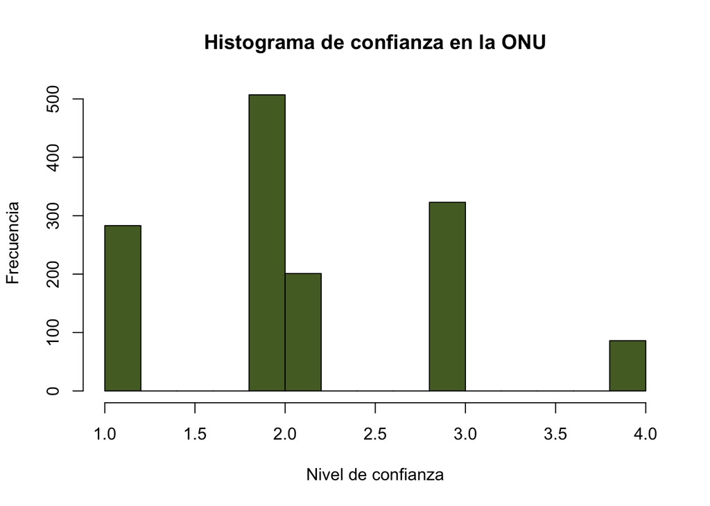

```r
hist(data$ONU, xlab = "Nivel de confianza", ylab = "Frecuencia", col = "darkolivegreen", main = "Histograma de confianza en la ONU")
```

- Se observa que 2 es el grado mayor votado e confianza a la ONU. Asimismo el 50% de personas eligió una confianza mayor o igual a 2, mientras que el otro 50% tiene una confianza menor o igual a 2. Cabe mencionar que la cola de la curva esta a la derecha, por lo que exsite mayor cantidad de datos en las puntuaciones de valores bajos, es decir, existe una asimetría positiva (muy pocas personas confian en la ONU).

**- Variable confianza en el Fondo Monetario Internacional (FMI)**

```r
Mode(data$FMI,na.rm = T)
```

```
## [1] 1
## attr(,"freq")
## [1] 674
```

```r
Median(data$FMI,na.rm = T)
```

```
## [1] 1.628247
```

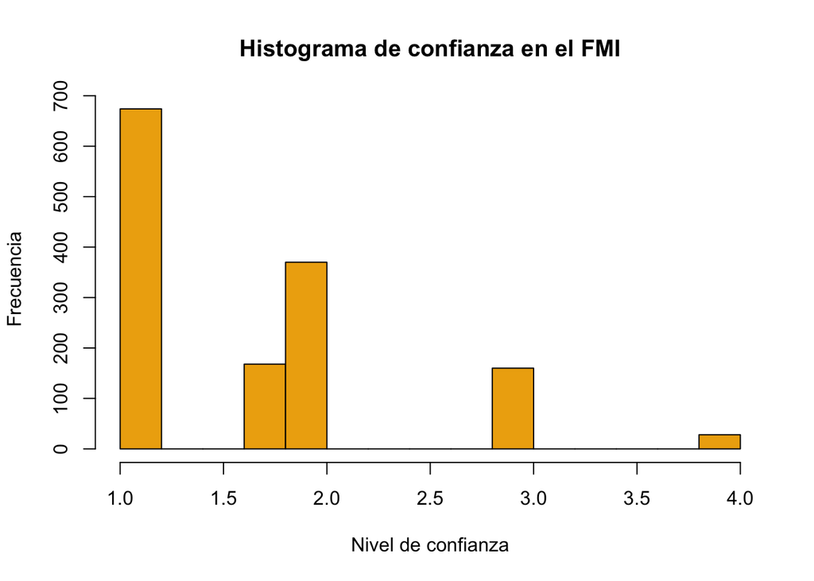

```r
hist(data$FMI, main="Histograma de confianza en el FMI", xlab = "Nivel de confianza", ylab = "Frecuencia", col = "darkgoldenrod2")
```

**- Variable confianza en la Organización de Estados Americanos (OEA)**

```r
table(data$OEA)
```

```
##
##                1                2 2.14262023217247                3
##              298              516              194              314
##                4
##               78
```

```r
summary(data$OEA)
```

```
##    Min. 1st Qu.  Median    Mean 3rd Qu.    Max.
##   1.000   2.000   2.000   2.143   3.000   4.000
```

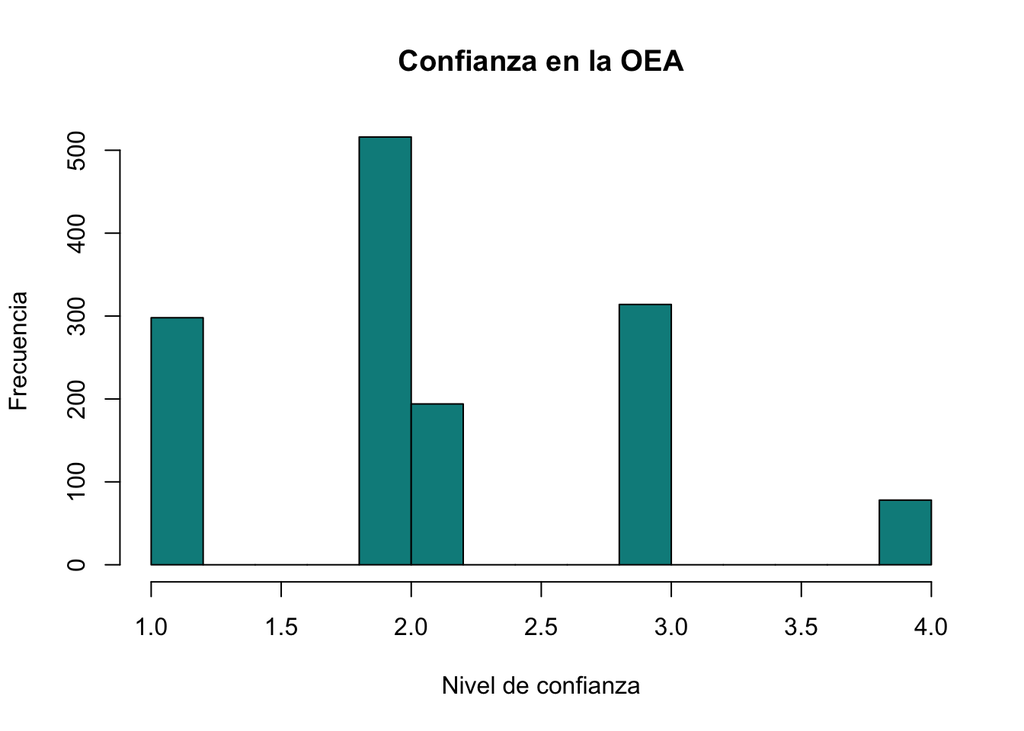

```r
hist(data$OEA, main="Confianza en la OEA", xlab = "Nivel de confianza", ylab = "Frecuencia", col = "cyan4")
```

- Se observa que la mayoría de personas tienen un grado de confianza de nivel 2 en la OEA. Asimismo el 50% de personas eligió una confianza mayor o igual a 2. En esta misma linea se osberva que hay una asimetría positiva, ya que los valores se concentran en los más bajos. Sin embargo, a diferencia del FMI, la confianza parecería ser mayor.

## b. Variables independientes

**- Variable sexo**

```r
library(DescTools)
library(ggplot2)
table(data$sexo)
```

```
##
## Hombre  Mujer
##    702    698
```

```r
Mode(data$sexo, na.rm = T)
```

```
## [1] Hombre
## attr(,"freq")
## [1] 702
## Levels: Hombre Mujer
```

```r
t0=as.data.frame(table(data$sexo))
#install.packages("lessR")
library(lessR)
```

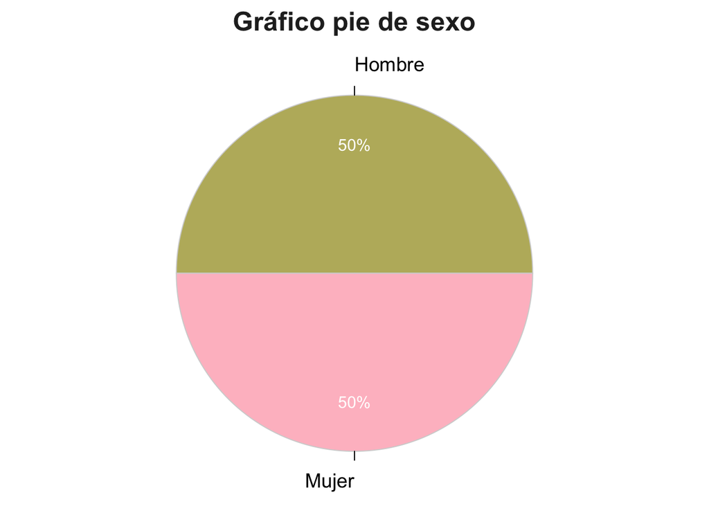

[output not shown]

```r
PieChart(Var1, hole = 0, values = "%", data = t0,
         fill = c("darkkhaki", "pink"), main = "Gráfico pie de sexo")
```

- Como se puede observar, del total de los encuestados 702 fueron hombres (el valor más frecuente) y 698 mujeres. Por lo tanto, en el gráfico de piese observa que apróximadamente la mitad fueron hombres, y la otra mitad mujeres.

**- Variable edad**

```r
summary(data$Edad)
```

```
##    Min. 1st Qu.  Median    Mean 3rd Qu.    Max.
##   18.00   27.00   38.00   40.16   51.00   86.00
```

```r
Mode(data$Edad, na.rm = T)
```

```
## [1] 18
## attr(,"freq")
## [1] 49
```

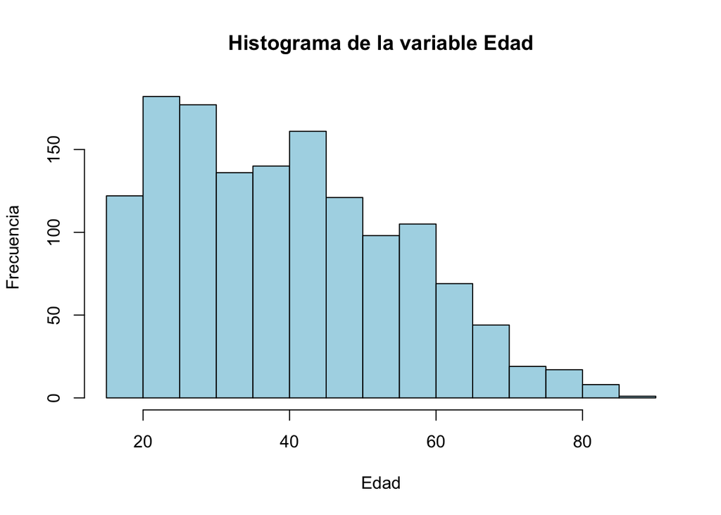

```r
hist(data$Edad, main = "Histograma de la variable Edad", xlab = "Edad", ylab = "Frecuencia", col = "lightblue")
```

**- Ingreso socioeconómico**

```r
Mode(data$Ingresos, na.rm = T)
```

```
## [1] Medio
## attr(,"freq")
## [1] 947
## Levels: No sabe < Bajo < Medio < Alto
```

```r
table(data$Ingresos)
```

```
##
## No sabe    Bajo   Medio    Alto
##      17     324     947     112
```

```r
tabla_ingresos=table(data$Ingresos)
tabla_ingresos1=prop.table(tabla_ingresos)*100
round(tabla_ingresos1, digits = 2)
```

```
##
## No sabe    Bajo   Medio    Alto
##    1.21   23.14   67.64    8.00
```

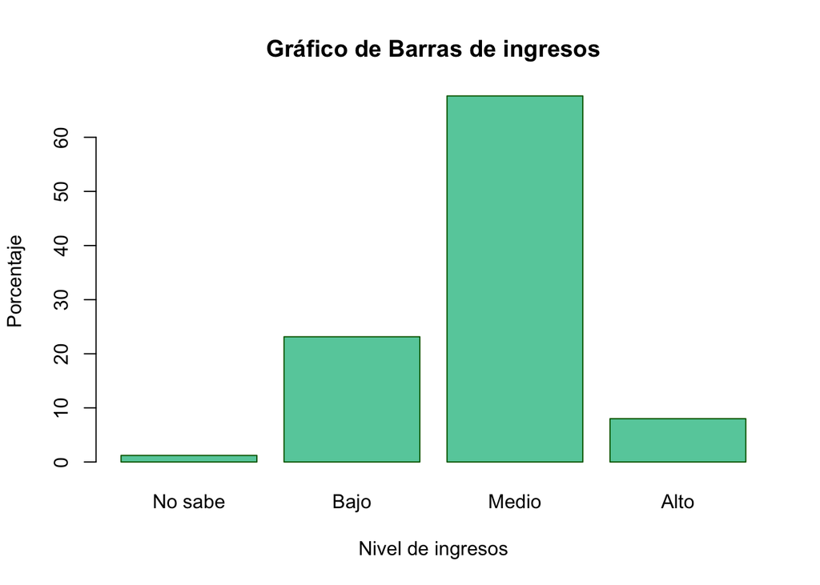

```r
barplot(tabla_ingresos1, main = "Gráfico de Barras de ingresos",
xlab = "Nivel de ingresos",
ylab = "Porcentaje", col = "aquamarine3", border = "darkgreen")
```

**- Variable ideología**

```r
summary(data$Ideologia)
```

```
## Izquierda    Centro   Derecha
##       176       812       412
```

```r
tabla_ideologia=table(data$Ideologia)
tabla_ideologia1=prop.table(tabla_ideologia)*100
round(tabla_ideologia1, digits = 2)
```

```
##
## Izquierda    Centro   Derecha
##     12.57     58.00     29.43
```

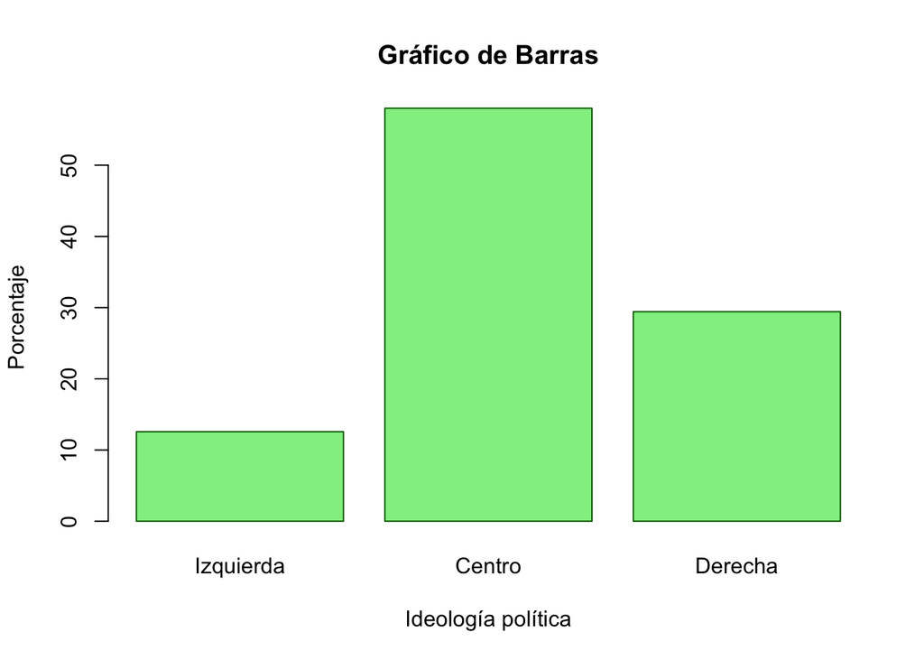

```r
barplot(tabla_ideologia1, main = "Gráfico de Barras",
xlab = "Ideología política",
ylab = "Porcentaje", col = "lightgreen", border = "darkgreen")
```

**- Interés en la política:**

```r
Mode(data$interes_pol, na.rm = T)
```

```
## [1] Poco
## attr(,"freq")
## [1] 545
## Levels: Nada Poco Algo Mucho
```

```r
summary(data$interes_pol)
```

```
##  Nada  Poco  Algo Mucho
##   537   545   219    99
```

```r
tabla_interes=table(data$interes_pol)
tabla_interes1=prop.table(tabla_interes)*100
round(tabla_interes1, digits = 2)
```

```
##
##  Nada  Poco  Algo Mucho
## 38.36 38.93 15.64  7.07
```

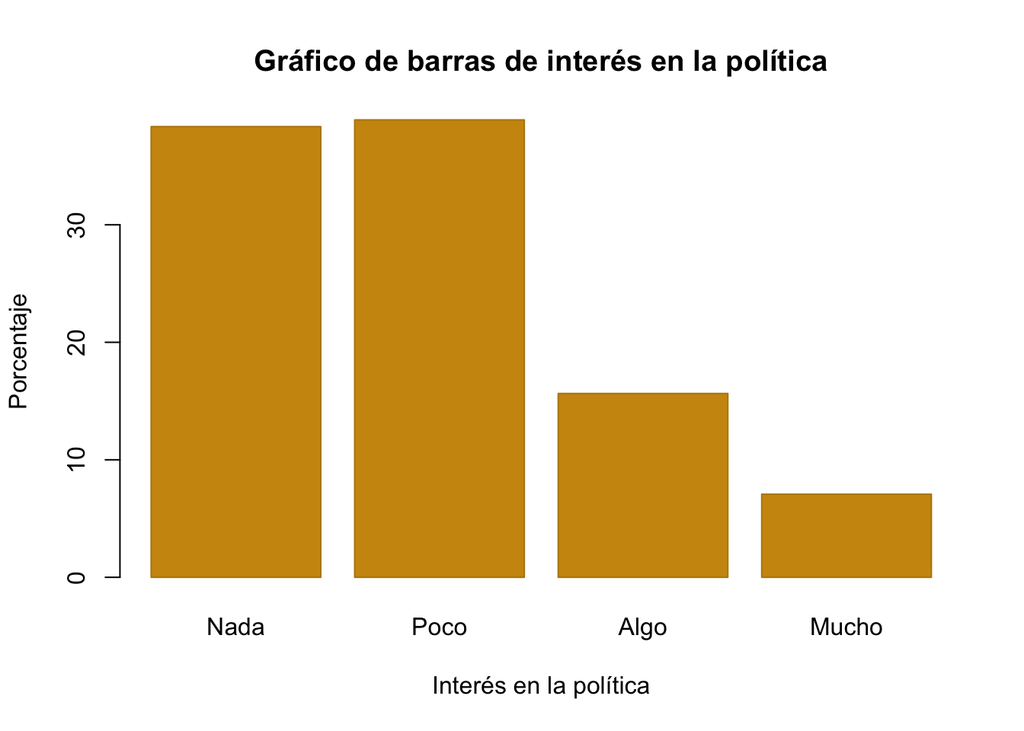

```r
barplot(tabla_interes1, main = "Gráfico de barras de interés en la política",
xlab = "Interés en la política",
ylab = "Porcentaje", col = "darkgoldenrod3", border = "darkgoldenrod")
```

- La mayoría de personas encuestadas (38.8%) tiene un poco interés en la política. Le sigue quienes tienen nada de interés (38.4%), algo (15.7%) y mucho (7.1%).

**- Preocupación por una guerra**

```r
Mode(data$preo_guerra, na.rm = T)
```

```
## [1] Mucho
## attr(,"freq")
## [1] 801
## Levels: Nada Poco Bastante Mucho
```

```r
tabla_preo=table(data$preo_guerra)
tabla_preo1=prop.table(tabla_preo)*100
round(tabla_preo1, digits = 2)
```

```
##
##     Nada     Poco Bastante    Mucho
##     3.79    10.14    28.86    57.21
```

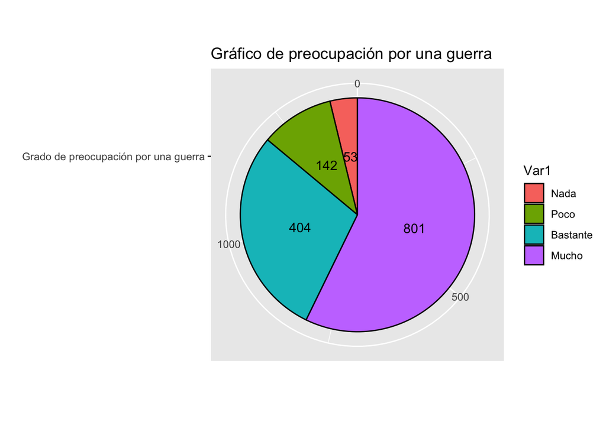

```r
t3=as.data.frame(table(data$preo_guerra))

ggplot(t3,aes(x="Grado de preocupación por una guerra",y=Freq, fill=Var1))+
  geom_bar(stat = "identity",color="black")+
  geom_text(aes(label=Freq),
            position=position_stack(vjust=0.5))+coord_polar(theta="y")+ggtitle("Gráfico de preocupación por una guerra")+xlab("") + ylab(" ")
```

**- Libertad de elección y control**

```r
library(DescTools)
Mode(data$lib_con,na.rm = T)
```

```
## [1] 10
## attr(,"freq")
## [1] 303
```

```r
Median(data$lib_con,na.rm = T)
```

```
## [1] 8
```

- La mayor cantidad de personas se sienten con mucha libertad de elección y control. Asimismo, la mitad de los encuestados asignaron a su libertad de elección y control un puntaje menor o igual a 8 y la otra mitad le asignaron un valor mayor o igual a 8.

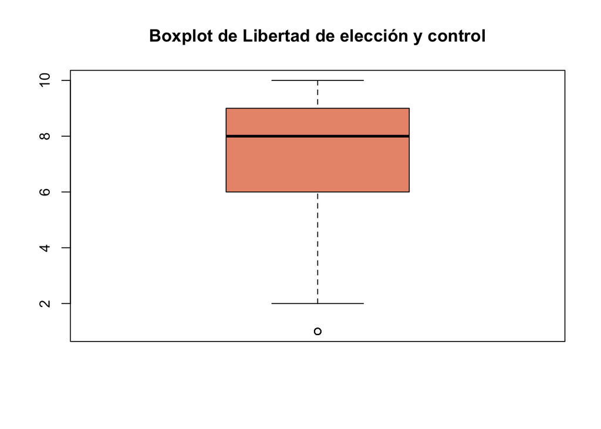

```r
boxplot(data$`Q48: How much freedom of choice and control`, main="Boxplot de Libertad de elección y control", col = "darksalmon")
```

- Se observa que solo existe un caso atípico y que más del 75% de encuestados considera que tiene capacidad de elección y libertad. De esta forma, son pocas las personas que marcaron un nivel bajo

**- Libertad o igualdad**

```r
Mode(data$lib_igualdad,na.rm = T)
```

```
## [1] Igualdad
## attr(,"freq")
## [1] 803
## Levels: No sabe Libertad Igualdad
```

- La mayor cantidad de personas prefieren la igualdad que la libertad.

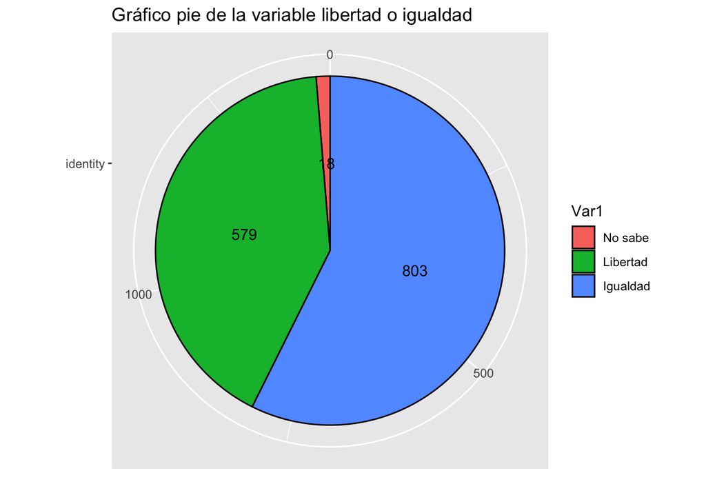

```r
library(ggplot2)
t1=as.data.frame(table(data$lib_igualdad))

ggplot(t1,aes(x="identity",y=Freq, fill=Var1))+
  geom_bar(stat = "identity",color="black")+
  geom_text(aes(label=Freq),
            position=position_stack(vjust=0.5))+coord_polar(theta="y")+ggtitle("Gráfico pie de la variable libertad o igualdad")+xlab("") + ylab(" ")
```

- Se observa que la mayoría de personas prefiere la igualdad; sin embargo, la diferencia no es mucha.

**- Libertad o seguridad**

```r
Mode(data$lib_seguridad,na.rm = T)
```

```
## [1] Seguridad
## attr(,"freq")
## [1] 1170
## Levels: No sabe Libertad Seguridad
```

- Las mayor cantidad de personas prefieren la seguridad que la libertad.

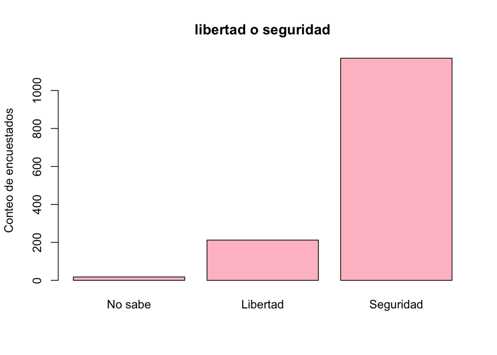

```r
t2=as.data.frame(table(data$lib_seguridad))
barplot(table(data$lib_seguridad),col="pink",
        xlab=NULL,
        ylab="Conteo de encuestados",
        main="libertad o seguridad")
```

- Se observa que la mayoría de personas prefiere la seguridad. Además, a diferencia del gráfico de la variable libertad o seguridad, la diferencia entre las personas que prefieren seguridad antes que libertad es notoria.

**- Objetivos del país**

```r
Mode(data$objetivos_pais,na.rm = T)
```

```
## [1] Crecimiento economico alto
## attr(,"freq")
## [1] 877
## 5 Levels: No sabe Crecimiento economico alto ... Embellecer las ciudades
```

- La mayor cantidad de personas consideran que los objetivos del país deben de enfocarse en un alto nivel de crecmiento económico.

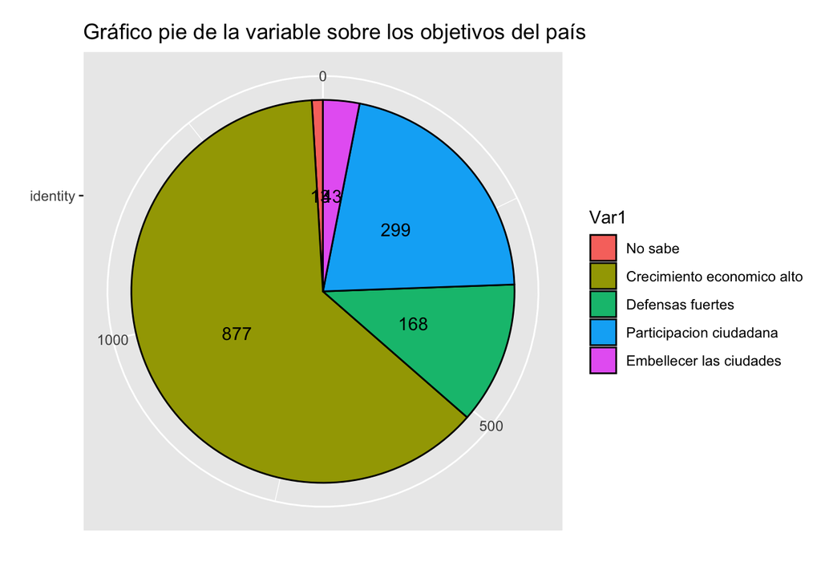

```r
t3=as.data.frame(table(data$objetivos_pais))

ggplot(t3,aes(x="identity",y=Freq, fill=Var1))+
  geom_bar(stat = "identity",color="black")+
  geom_text(aes(label=Freq),
            position=position_stack(vjust=0.5))+coord_polar(theta="y")+ggtitle("Gráfico pie de la variable sobre los objetivos del país")+xlab("") + ylab(" ")
```

- Se observa que la mayoría de personas prefiere que el pís se enfoque en un alto crecimiento económico antes de hacer nuestras ciudades un poco más bellas

**- Objetivos del encuestado**

```r
Mode(data$objetivos_encuestado,na.rm = T)
```

```
## [1] Mantener el orden
## attr(,"freq")
## [1] 745
## 5 Levels: No sabe ... Proteger la libertad de expresion
```

- Las mayor cantidad de personas consideran que sus objetivos deben de enfocarse en mantener orden en la nación.

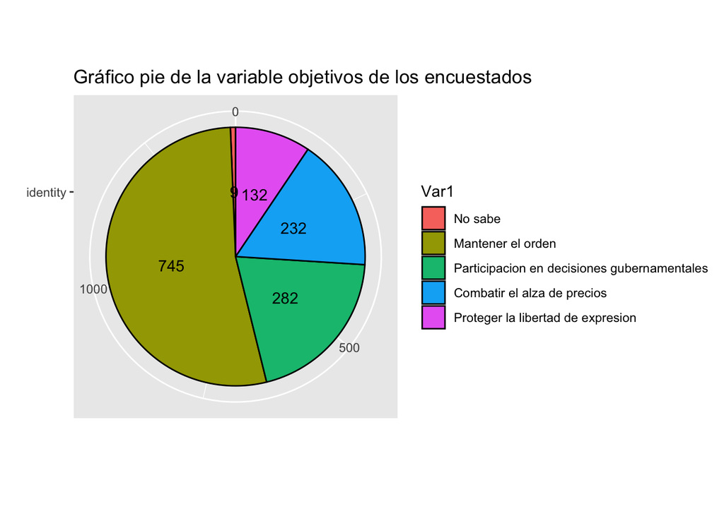

```r
t4=as.data.frame(table(data$objetivos_encuestado))

ggplot(t4,aes(x="identity",y=Freq, fill=Var1))+
  geom_bar(stat = "identity",color="black")+
  geom_text(aes(label=Freq),
            position=position_stack(vjust=0.5))+coord_polar(theta="y")+ggtitle("Gráfico pie de la variable objetivos de los encuestados")+xlab("") + ylab(" ")
```

- Se observa que la mayoría de personas prefiere enfocarse en mantener orden en la nación.

**- Importancia de la democracia**

```r
Mode(data$democracia,na.rm = T)
```

```
## [1] 10
## attr(,"freq")
## [1] 642
```

```r
Median(data$democracia,na.rm = T)
```

```
## [1] 9
```

- Las mayor cantidad de personas le da una gran importancia a la democracia. Asimismo, la mitad de los encuestados asignaron a la importancia de la democracia un puntaje menor o igual a 9 y la otra mitad le asignaron un valor mayor o igual a 9.

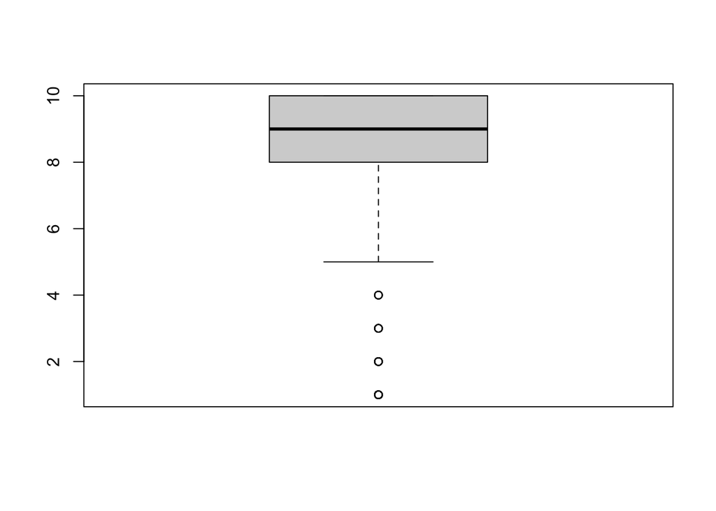

```r
boxplot(data$democracia)
```

- Se observa que no existen muchos casos atípicos y que más del 75% de encuestados considera que la importancia a la democracia es relevante.

**- Proximidad al mundo**

```r
Mode(data$mundo,na.rm = T)
```

```
## [1] Cerca
## attr(,"freq")
## [1] 465
## Levels: No sabe < Muy cerca < Cerca < No muy cerca < Para nada cerca
```

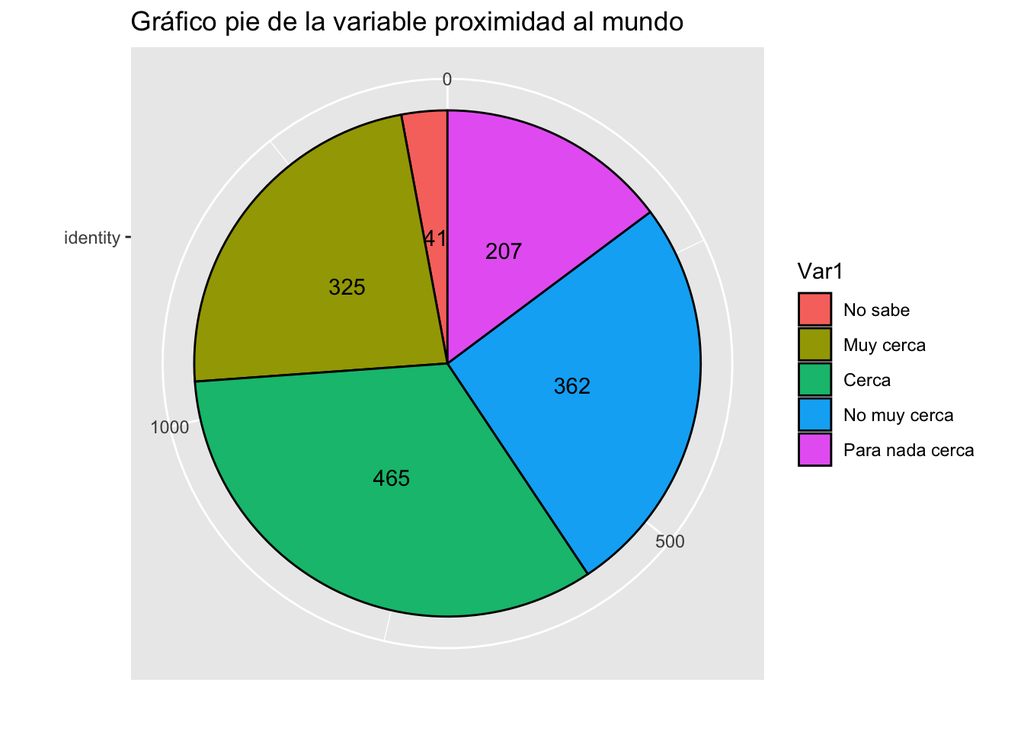

```r
t5=as.data.frame(table(data$mundo))

ggplot(t5,aes(x="identity",y=Freq, fill=Var1))+
  geom_bar(stat = "identity",color="black")+
  geom_text(aes(label=Freq),
            position=position_stack(vjust=0.5))+coord_polar(theta="y")+ggtitle("Gráfico pie de la variable proximidad al mundo")+xlab("") + ylab(" ")
```

- Se observa que la mayor cantidad de personas consideran que se encuentran cercanas al mundo.

**- Nivel de educación**

```r
Mode(data$educacion,na.rm = T)
```

```
## [1] Secundario
## attr(,"freq")
## [1] 687
## Levels: Primario < Secundario < Post-secundario
```

- Se observa que la mayor cantidad de participantes alcanzó el nivel educativo secundario.

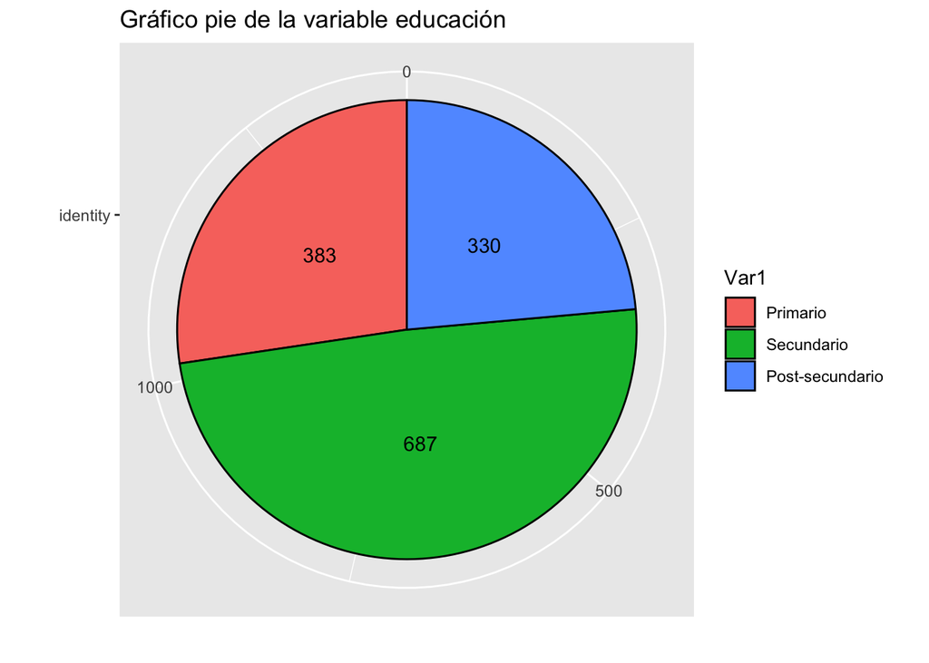

```r
t6=as.data.frame(table(data$educacion))

ggplot(t6,aes(x="identity",y=Freq, fill=Var1))+
  geom_bar(stat = "identity",color="black")+
  geom_text(aes(label=Freq),
            position=position_stack(vjust=0.5))+coord_polar(theta="y")+ggtitle("Gráfico pie de la variable educación")+xlab("") + ylab(" ")
```

- Se observa que la mayor cantidad de personas alcanzó el nivel secundario.

### Creación de la variable Confianza en las Organizaciones Internacionales por Componentes Principales

Variables a usar: - ONU - FMI - OEA

```r
comp_prin=subset(data,select=c("ONU", "OEA", "FMI"))
library(polycor)
library(psych)
str(comp_prin)
```

```
## 'data.frame':    1400 obs. of  3 variables:
##  $ ONU: num  2 2 3 2 1 2 2 3 3 2 ...
##  $ OEA: num  4 2 3 2 1 2 2 1 3 2 ...
##  $ FMI: num  1 2 1 2 1 2 2 1 1 1 ...
```

```r
cor(comp_prin)
```

```
##           ONU       OEA       FMI
## ONU 1.0000000 0.8117439 0.4255330
## OEA 0.8117439 1.0000000 0.3852822
## FMI 0.4255330 0.3852822 1.0000000
```

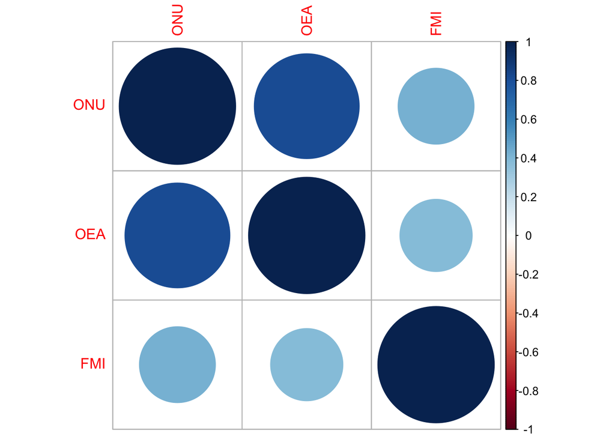

```r
library(corrplot)
corrplot(cor(comp_prin))
```

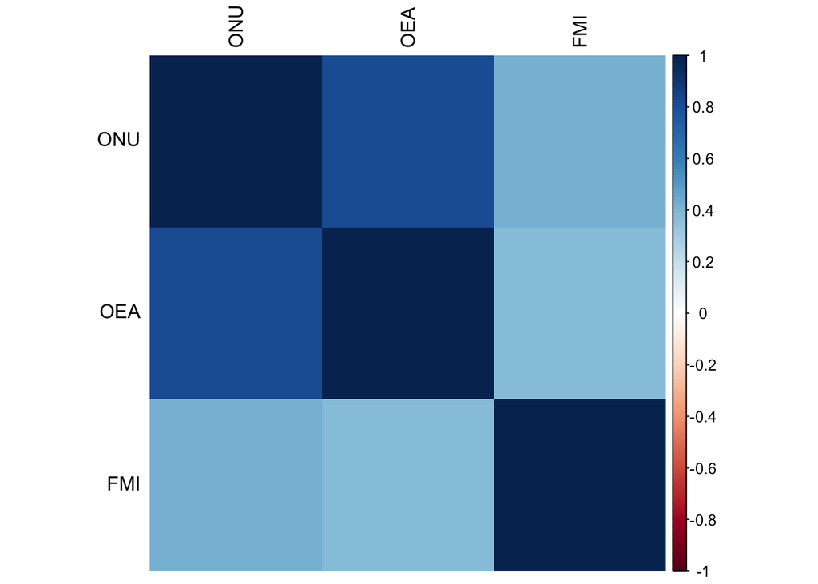

```r
corrplot(cor(comp_prin), # Matriz de correlación
method = "shade", # Método para el gráfico de correlación
type = "full", # Estilo del gráfico (también "upper" y "lower")
diag = TRUE, # Si TRUE (por defecto), añade la diagonal
tl.col = "black", # Color de las etiquetas
bg = "white", # Color de fondo
title = "",
col = NULL)
```

```r
# pruebas
library(psych)
psych::KMO(comp_prin)
```

```
## Kaiser-Meyer-Olkin factor adequacy
## Call: psych::KMO(r = comp_prin)
## Overall MSA =  0.6
## MSA for each item =
##  ONU  OEA  FMI
## 0.57 0.57 0.87
```

```r
corMatrix=cor(comp_prin)
cortest.bartlett(corMatrix,n=nrow(comp_prin))$p.value>0.05
```

```
## [1] FALSE
```

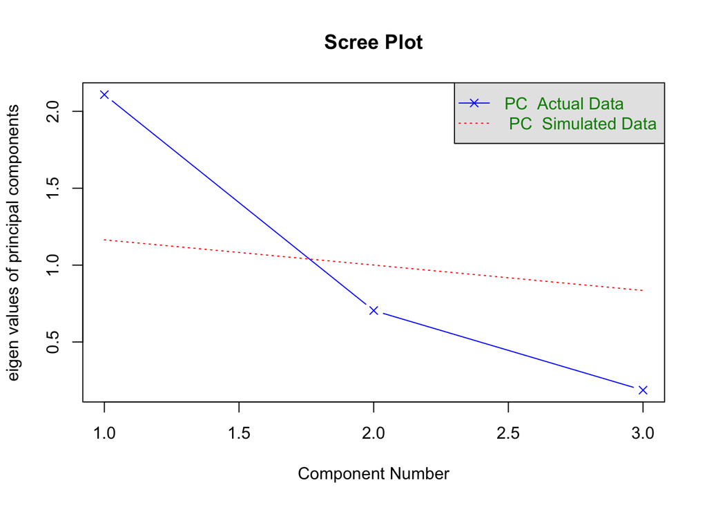

```
## Parallel analysis suggests that the number of factors =  NA  and the number of components =  1
```

```r
fa.parallel(corMatrix, fm="pa", fa="pc", main = "Scree Plot")
```

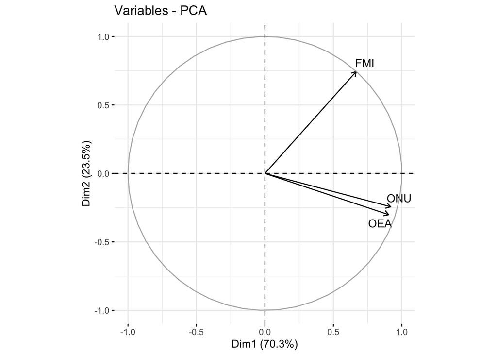

```r
library(FactoMineR)
res.pca <- PCA(comp_prin, graph = FALSE)
library(FactoMineR)
library(factoextra)
fviz_pca_var(res.pca, col.var = "black",repel = TRUE)
```

```r
eig.val <-get_eig(res.pca)
eig.val
```

```
##       eigenvalue variance.percent cumulative.variance.percent
## Dim.1  2.1084158        70.280526                    70.28053
## Dim.2  0.7046544        23.488481                    93.76901
## Dim.3  0.1869298         6.230993                   100.00000
```

Añadir variable

```r
comp1<- pca(comp_prin,nfactors = 1,rotate = "varimax")
comp<-as.data.frame(comp1$scores)
summary(comp$PC1)
```

```
##     Min.  1st Qu.   Median     Mean  3rd Qu.     Max.
## -1.51363 -0.43877 -0.01374  0.00000  0.63609  2.98603
```

```r
data$con_org<- (comp$PC1)
data$con_org=as.numeric(data$con_org)

library(BBmisc)
data$con_organizaciones= normalize(data$con_org,
                                   method = "range",
                                   margin=2,
                                   range = c(0, 100))
data$con_organizaciones=as.numeric(data$con_organizaciones)
```

# 2. Análisis

## a. Hipótesis 1: Considerando la revisión de la literatura, es probable que las variables clásicas, sexo, educación, ingresos, ideología y edad, permitan explicar la confianza en las organizaciones internacionales. Una mayor confianza en las OI probablemente se relacionen a niveles altos de educación, ingresos altos, una ideología de izquierda y a personas jóvenes.

```r
library(fastDummies)
data=dummy_cols(data,  select_columns = c("sexo","educacion", "Ingresos", "Ideologia"))

ml1 <- lm(con_organizaciones ~ sexo_Hombre + `educacion_Post-secundario` + Ideologia_Derecha + Ingresos_Bajo + Edad, data=data)

ml2 <- lm(con_organizaciones ~  sexo_Hombre + `educacion_Post-secundario` + Ideologia_Izquierda + Ingresos_Alto+ Edad, data=data)

ml3 <- lm(con_organizaciones ~ sexo_Mujer + `educacion_Post-secundario` + Ideologia_Derecha + Ingresos_Medio + Edad, data=data)

ml4 <- lm(con_organizaciones ~  `educacion_Post-secundario` + Ideologia_Derecha + Ingresos_Medio + Edad, data=data)
```

```r
library(stargazer)
stargazer(ml1, ml2, ml3, ml4,
          type= "html",
          title = "Modelos de regresión lineal múltiple de las variables clásicas",
          dep.var.labels   = "Confianza en las Organizaciones Internacionales",
          digits = 3,
          omit.stat = c("rsq", "f"),
          align=TRUE)
```

**Modelos de regresión lineal múltiple de las variables clásicas**

|  | *Dependent variable:* |  |  |  |
| --- | --- | --- | --- | --- |
|  | Confianza en las Organizaciones Internacionales |  |  |  |
|  | (1) | (2) | (3) | (4) |
| sexo_Hombre | -2.445** | -1.934 |  |  |
|  | (1.179) | (1.186) |  |  |
| sexo_Mujer |  |  | 2.419** |  |
|  |  |  | (1.178) |  |
| `educacion_Post-secundario` | 4.405*** | 5.156*** | 4.812*** | 4.691*** |
|  | (1.407) | (1.412) | (1.392) | (1.393) |
| Ideologia_Derecha | 4.026*** |  | 4.242*** | 4.100*** |
|  | (1.290) |  | (1.288) | (1.287) |
| Ingresos_Bajo | -4.455*** |  |  |  |
|  | (1.425) |  |  |  |
| Ideologia_Izquierda |  | -0.075 |  |  |
|  |  | (1.787) |  |  |
| Ingresos_Alto |  | -0.305 |  |  |
|  |  | (2.197) |  |  |
| Ingresos_Medio |  |  | 3.974*** | 3.787*** |
|  |  |  | (1.263) | (1.261) |
| Edad | -0.074* | -0.086** | -0.078** | -0.080** |
|  | (0.038) | (0.038) | (0.038) | (0.038) |
| Constant | 36.664*** | 36.899*** | 30.498*** | 31.989*** |
|  | (1.832) | (1.803) | (2.102) | (1.974) |
| Observations | 1,400 | 1,400 | 1,400 | 1,400 |
| Adjusted R<sup>2</sup> | 0.027 | 0.013 | 0.027 | 0.025 |
| Residual Std. Error | 21.922 (df = 1394) | 22.084 (df = 1394) | 21.921 (df = 1394) | 21.946 (df = 1395) |
| *Note:* | p<0.1; p<0.05; p<0.01 |  |  |  |

**Sobre el modelo**

- 1. Como el p-valor (3.14e-08) es menor a 0.05, se rechaza la hipótesis nula (H0: El modelo no es válido), por lo que el modelo sí es válido.
- 2. El modelo explica el 2.7% de la variabilidad de confianza en las organizaciones internacionales, un porcentaje bajo.
- 3. Como todos los p-valores de las variables son menores a 0.05, se concluye sí aportan al modelo.
- 4. Edad tiene una relación inversa con la confianza en las organizaciones internacionales, es decir, las personas jóvenes confian mas mientras que las mayores menos.
- 5. Ecuación final: Confianza en las organizaciones internacionales = 30.49769 + (2.41933*Sexo_Mujer) + (4.81167*educacion_Post-secundario) + (4.24173*Ideologia_Derecha) + (3.97434+Ingresos_Medios) + (-0.07809*Edad)

## b. Hipótesis 2. Luego de la revisión de literatura, las personas ya sea que prefieren libertad, seguridad o igualdad tendrán un alto grado de confianza en las organizaciones internacionales, ya que estos son algunos de los valores que promueven

```r
ml5 <- lm(con_organizaciones ~ interes_pol + democracia + preo_guerra + lib_igualdad + objetivos_encuestado + mundo , data=data)
summary(ml5)
```

```
##
## Call:
## lm(formula = con_organizaciones ~ interes_pol + democracia +
##     preo_guerra + lib_igualdad + objetivos_encuestado + mundo,
##     data = data)
##
## Residuals:
##    Min     1Q Median     3Q    Max
## -42.06 -12.70  -1.14  12.10  73.21
##
## Coefficients:
##                                                                 Estimate
## (Intercept)                                                     14.31330
## interes_polPoco                                                  1.29771
## interes_polAlgo                                                  2.86623
## interes_polMucho                                                 1.12438
## democracia                                                       0.85039
## preo_guerraPoco                                                  7.08851
## preo_guerraBastante                                              7.84977
## preo_guerraMucho                                                10.50162
## lib_igualdadLibertad                                            -2.13305
## lib_igualdadIgualdad                                            -0.69290
## objetivos_encuestadoMantener el orden                            2.67899
## objetivos_encuestadoParticipacion en decisiones gubernamentales  3.74193
## objetivos_encuestadoCombatir el alza de precios                 -0.02888
## objetivos_encuestadoProteger la libertad de expresion            3.00996
## mundo.L                                                         -4.22054
## mundo.Q                                                         -5.29820
## mundo.C                                                          2.04862
## mundo^4                                                         -1.45023
##                                                                 Std. Error
## (Intercept)                                                        9.19878
## interes_polPoco                                                    1.34008
## interes_polAlgo                                                    1.76566
## interes_polMucho                                                   2.41319
## democracia                                                         0.30656
## preo_guerraPoco                                                    3.54164
## preo_guerraBastante                                                3.22876
## preo_guerraMucho                                                   3.14210
## lib_igualdadLibertad                                               5.26421
```

[output cut: 38 more lines]

```
## lib_igualdadIgualdad                                            0.894848
## objetivos_encuestadoMantener el orden                           0.718053
## objetivos_encuestadoParticipacion en decisiones gubernamentales 0.617162
## objetivos_encuestadoCombatir el alza de precios                 0.996923
## objetivos_encuestadoProteger la libertad de expresion           0.693184
## mundo.L                                                         0.083277 .
## mundo.Q                                                         0.013491 *
## mundo.C                                                         0.199069
## mundo^4                                                         0.215768
## ---
## Signif. codes:  0 '***' 0.001 '**' 0.01 '*' 0.05 '.' 0.1 ' ' 1
##
## Residual standard error: 21.81 on 1382 degrees of freedom
## Multiple R-squared:  0.04828,    Adjusted R-squared:  0.03657
## F-statistic: 4.124 on 17 and 1382 DF,  p-value: 0.00000003529
```

### Bibliografía:

Brewer, P.R., Gross, K., Aday, S. and Willnat, L. (2004). International Trust and Public Opinion About World Affairs. American Journal of Political Science, 48: 93-109. https://doi-org.ezproxybib.pucp.edu.pe/10.1111/j.0092-5853.2004.00058.x

Burgos, J. (2019, 12 abril). Las organizaciones internacionales y sus recursos de poder. Una propuesta analítica. Scielo. Recuperado 29 de octubre de 2021, de http://www.scielo.org.co/scielo.php?script=sci_arttext&pid=S0121-51672019000100149

Cabeza De Vergara, L., & Muñoz, A. (2010, 10 enero). Análisis del proceso de toma de decisiones, visión desde la PYME y la Gran Empresa de Barranquilla. Redalyc. Recuperado 29 de octubre de 2021, de https://www.redalyc.org/pdf/4096/409634363002.pdf

Edwards, M. S. (2009). Public support for the international economic organizations: Evidence from developing countries. Review of International Organizations, 4(2), 185- 209.

FMI. (2018). Informe del FMI 2017. Recuperado 29 de octubre de 2021, de https://www.imf.org/external/pubs/ft/ar/2017/eng/assets/languages/IMF-AR17-Spanish.pdf

Hessami, Zohal. (2011). What Determines Trust in International Organizations? An Empirical Analysis for the IMF, the World Bank, and the WTO, 1-31.

INEI. (2018, 6 agosto). Perú recibe cuarta misión del Fondo Monetario Internacional de Asistencia Técnica en Cuentas Nacionales por Sectores Institucionales Anuales y Trimestrales. Recuperado 29 de octubre de 2021, de https://www.inei.gob.pe/prensa/noticias/peru-recibe-cuarta-mision-del-fondo-monetario-internacional-de-asistencia-tecnica-en-cuentas-nacionales-por-sectores-institucionales-anuales-y-trimestrales-10889/

Leco, C., & Belman, J. (2018). El papel de las organizaciones internacionales en la protección de los derechos humanos de los migrantes en México. Dialnet. Recuperado 29 de octubre de 2021, de https://dialnet.unirioja.es/descarga/articulo/6577165.pdf

Naciones Unidas. (2017). Marco de Cooperación de las Naciones Unidas para el Desarrollo en el Perú 2017-2021. Recuperado 29 de octubre de 2021, de https://peru.un.org/es/48770-marco-de-cooperacion-de-las-naciones-unidas-para-el-desarrollo-en-el-peru-2017-2021

Nuño, A. (2020). Democracia y organismos internacionales. INEI. Recuperado 31 de octubre de 2021, de https://www.ine.mx/wp-content/uploads/2021/02/CDCD-33.pdf

Organización de Estados Americanos. (2017). La OEA y Perú inician preparativos de la VIII Cumbre de las Américas. OEA. Recuperado 29 de octubre de 2021, de https://www.oas.org/es/centro_noticias/fotonoticia.asp?sCodigo=FNC-22071

Organización de Estados Americanos.(2021). La Misión de Observación Electoral de la OEA en Perú saluda a las autoridades peruanas por la implementación de sus recomendaciones. Recuperado 29 de octubre de 2021, de http://www.oas.org/documents/spa/press/Informe-Preliminar-MOE-Peru2020-FINAL.pdf Pastor, J.A. Curso de Derecho Internacional Público y Organizaciones Internacionales. 12ma edición. Madrid: Tecnos, 2008, p. 659 –663.

Rathbun, B. C. (2011). The “Magnificent Fraud”: Trust, International Cooperation, and the Hidden Domestic Politics of American Multilateralism after World War II. International Studies Quarterly, 55(1), 1–21. https://doi-org.ezproxybib.pucp.edu.pe/10.1111/j.1468-2478.2010.00633.x

Sparr. P. (1998). Mortgaging Women’s Lives–Feminist Critiques of Structural Adjustment. (1998). Women’s International Network News, 24(1), 15.

Simons, P., & Handl, M. (2019). Relations of Ruling: A Feminist Critique of the United Nations Guiding Principles on Business and Human Rights and Violence against Women in the Context of Resource Extraction. Canadian Journal of Women & the Law, 31(1), 113–150. https://doi-org.ezproxybib.pucp.edu.pe/10.3138/cjwl.31.1.06

Shannon, M. (2009). Preventing War and Providing the Peace?: International Organizations and the Management of Territorial Disputes. Conflict Management & Peace Science, 26(2), 144–163. https://doi-org.ezproxybib.pucp.edu.pe/10.1177/0738894208101127

Torgler, B. (2008). Trust in international organizations: An empirical investigation focusing on the United Nations. Rev Int Org 3, 65–93. https://doi.org/10.1007/s11558-007-9022-1